# Suicide Rates and Economic Quality: Generalized Linear Mixed Effects Modelling

Ryan Gryder

## Introduction

In this project, we are interested in how economy quality as measured by Gross Domestic Product (GDP) is related to rate of suicide. An intuitive idea is that suicide rates should decrease as GDP increases since the latter reflects financial security. The goal of this work is to investigate if this is really true or if more nuanced and complicated relationships are occurring with regards to suicides. By accounting for the additional factors of age, sex, country, and time, we hope to shed some light on how/where future mental health efforts should be focused.

The data set was constructed by joining the following three data sets by country and year: 1. [United Nations Development Programme Annual Report 2018](https://www.undp.org/content/undp/en/home/librarypage/corporate/annual-report-2018.html) 2. [World Bank National Accounts Data: GDP (current US$)](https://data.worldbank.org/indicator/NY.GDP.MKTP.CD) 3. [World Health Organization: Suicide Prevention](https://www.who.int/health-topics/suicide#tab=tab_1)

```r
options(warn=-1)
suppressMessages(library(tidyverse))
suppressMessages(library(GGally))
suppressMessages(library(lme4))
suppressMessages(library(modelr))
suppressMessages(library(DBI))
suppressMessages(library(RSQLite))
suppressMessages(library(gridExtra))

con <- dbConnect(SQLite(), dbname = "suicide.db") # connect to database using SQLite
suic_db <- tbl(con, "table1") # database has single table of data

suic_db <- suic_db %>% select(country, year, sex, age, suicides_no, population, suicides_100k, GDP)

# set age levels for plotting purposes
suic_db$age <- factor(suic_db$age, levels = c('5-14 years', '15-24 years', '25-34 years',
                                            '35-54 years', '55-74 years', '75+ years'))
# a quick look at the data
suic_db %>% print(n = 4)
```

```
## # Source:   lazy query [?? x 8]
## # Database: sqlite 3.33.0 [C:\Users\Ryan\Dropbox\JOBS\Projects
## #   portfolio\Suicide\suicide.db]
##   country  year sex    age       suicides_no population suicides_100k   GDP
##   <chr>   <dbl> <chr>  <chr>           <dbl>      <dbl>         <dbl> <dbl>
## 1 Albania  1987 male   15-24 ye~          21     312900          6.71   796
## 2 Albania  1987 male   35-54 ye~          16     308000          5.19   796
## 3 Albania  1987 female 15-24 ye~          14     289700          4.83   796
## 4 Albania  1987 male   75+ years           1      21800          4.59   796
## # ... with more rows
```

## Exploratory Data Analysis

First, we construct visualizations to explore general patterns and relations between the variables. Hopefully, some initial insights can be gleaned to guide the statistical modelling. We start with univariate histograms of the continuous variables. Since some demographics exhibited no suicides in a particular country and year, the distribution of the strictly non-zero suicide portion of the data is visualized.

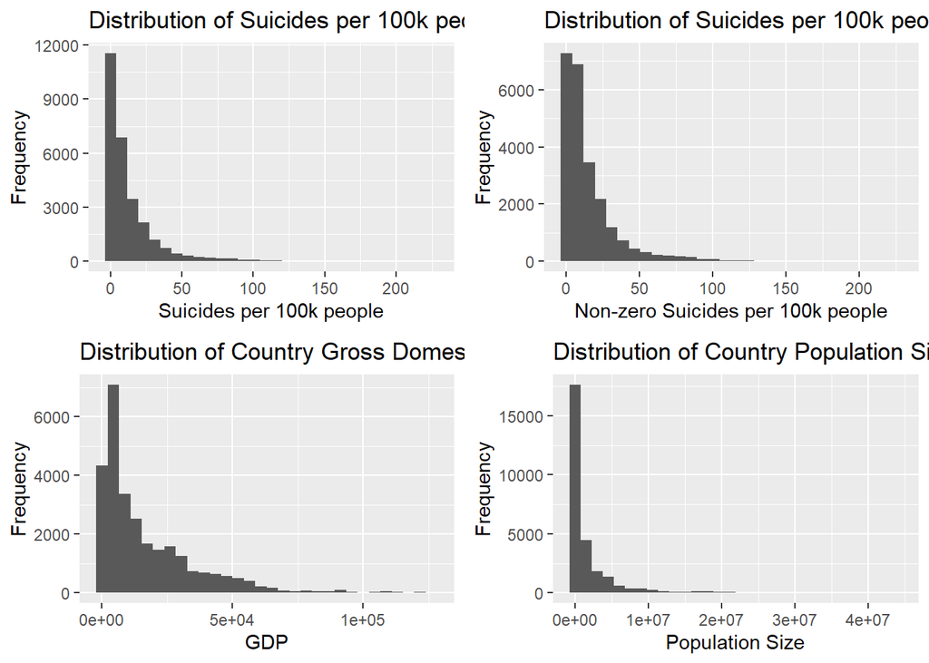

```r
# Histogram of suicides_100k
p1 <- suic_db %>% ggplot() + geom_histogram(aes(x = suicides_100k)) + xlab('Suicides per 100k people') +
  labs(title = 'Distribution of Suicides per 100k people') + ylab('Frequency')

# Histogram of  suicides_100k > 0
p2 <- suic_db %>% filter(suicides_100k > 0) %>% ggplot() + geom_histogram(aes(x = suicides_100k)) +
  xlab('Non-zero Suicides per 100k people') +
  labs(title = 'Distribution of Suicides per 100k people - Excluding Zeros') + ylab('Frequency')

# Histogram of GDP
p3 <- suic_db %>% ggplot() + geom_histogram(aes(x = GDP)) + ylab('Frequency') + xlab('GDP') +
  labs(title = 'Distribution of Country Gross Domestic Product')

# Histogram of population size
p4 <- suic_db %>% ggplot() + geom_histogram(aes(x =population)) + ylab('Frequency') + xlab('Population Size') +
  labs(title = 'Distribution of Country Population Size')

grid.arrange(p1, p2, p3, p4, nrow = 2)
```

```r
# This computes how much of the data consists of 0's for suicides_100k
cat('The number of zero suicide observations: ', nrow(suic_db %>% filter(suicides_100k == 0) %>% collect()))
```

```
## The number of zero suicide observations:  4281
```

```r
cat('The proportion of zero suicide observations: ', nrow(suic_db %>% filter(suicides_100k == 0) %>%
                                                            collect())/nrow(suic_db %>% collect()))
```

```
## The proportion of zero suicide observations:  0.1538821
```

The first histogram informs us that our response variable, suicides per 100,000 people, is heavily skewed to the right due to the presence of many zero and very small suicide proportions. In fact, about 15% of the observations are zeros. This suggests that it would be worthwhile to investigate the differences between the portion of the data representing zero suicides and the portion representing non-zero suicides. We will take this into account when building statistical models. After removing the sizeable chunk of zero suicide observations, the distribution of suicides per 100,000 people remains heavily skewed right; therefore, we will use a Generalized Linear Model (GLM) to model this response. The modelling specifics will be discussed later. GDP and demographic population size are also skewed right; much of the data is taken from small countries with low GDP.

Next, we construct some multivariate visualizations to explore the relationships between multiple variables and specifically how the number of suicides per 100,000 people varies across the other variable. We start by visualizing suicide proportions vs the categorical factors.

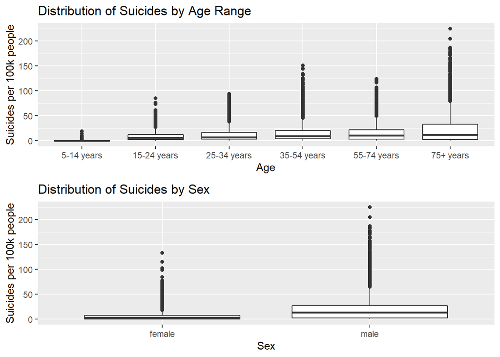

```r
# For plotting purposes
age_order <- c("5-14 years", "15-24 years", "25-34 years", "35-54 years", "55-74 years", "75+ years")

# suicides_100k vs age
p1 <- suic_db %>% ggplot(aes(x = fct_relevel(age, age_order), y = suicides_100k)) + geom_boxplot() + xlab('Age') +
  ylab('Suicides per 100k people') + labs(title = 'Distribution of Suicides by Age Range')

# suicides_100k vs sex
p2 <- suic_db %>% ggplot(aes(x = sex, y = suicides_100k)) + geom_boxplot() + xlab('Sex') +
  ylab('Suicides per 100k people') + labs(title = 'Distribution of Suicides by Sex')

# suicides_100k vs age and sex
p3 <- suic_db %>% ggplot(aes(x = sex, y = suicides_100k)) + geom_boxplot() + facet_wrap(~ fct_relevel(age, age_order)) + xlab('Sex') +
  ylab('Suicides per 100k people') + labs(title = 'Distribution of Suicides by Sex and Age Range')

grid.arrange(p1,p2, nrow = 2)
```

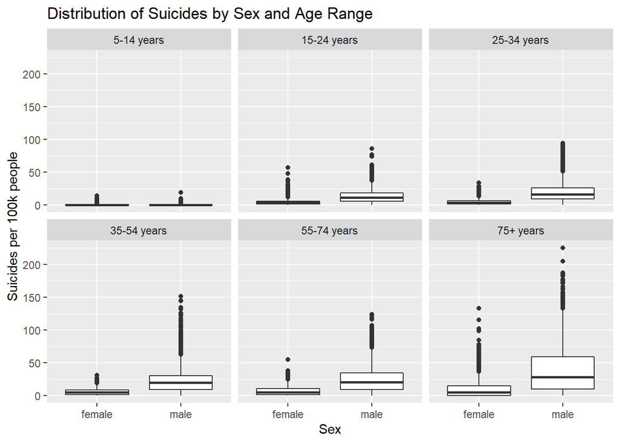

```r
p3
```

Now we use scatter plots with overlayed smooth curves (computed with locally weighted polynomial regression) to visualize the relationship between suicide rates and year while accounting for the categorical variables. The values of suicides per 100,000 people are grouped and consolidated for ease of visualization.

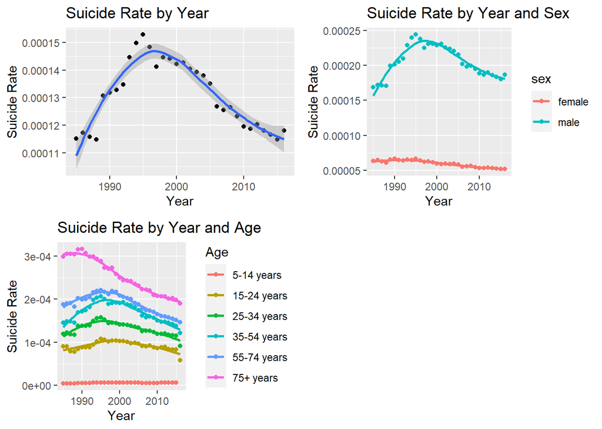

```r
# SQL queries are stored for potential future use. The multiple uses of 'sum()' is cumbersome, so we only fully compute it when we have to.

year_query <- suic_db %>% group_by(year) %>% summarise(suicides_prop = sum(suicides_no, na.rm = T)/sum(population, na.rm = T))

year_sex_query <- suic_db %>% group_by(year, sex) %>% summarise(suicides_prop = sum(suicides_no, na.rm = T)/sum(population, na.rm = T))

year_age_query <- suic_db %>% group_by(year, age) %>% summarise(suicides_prop = sum(suicides_no, na.rm = T)/sum(population, na.rm = T))

year_sex_age_query <- suic_db %>% group_by(year, sex, age) %>% summarise(suicides_prop = sum(suicides_no, na.rm = T)/sum(population, na.rm = T))

# suicide rate vs year
p1 <- year_query %>%
  ggplot(aes(x = year, y = suicides_prop)) + geom_point() + geom_smooth() + xlab('Year') + ylab('Suicide Rate') +
  labs(title = 'Suicide Rate by Year')

# suicide rate vs year and sex
p2 <- year_sex_query %>%
  ggplot(aes(x = year, y = suicides_prop)) + geom_point(aes(color = sex)) + geom_smooth(aes(color = sex), se = F) +
  xlab('Year') + ylab('Suicide Rate') + labs(title = 'Suicide Rate by Year and Sex')

# suicide rate vs year and age
p3 <- year_age_query %>%
  ggplot(aes(x = year, y = suicides_prop)) + geom_point(aes(color = fct_relevel(age, age_order))) + geom_smooth(aes(color = age), se = F) +
  xlab('Year') + ylab('Suicide Rate') + labs(title = 'Suicide Rate by Year and Age', color = 'Age')

# suicide rate vs year, sex, and age
p4 <- year_sex_age_query %>%
  ggplot(aes(x = year, y = suicides_prop)) + geom_point(aes(color = fct_relevel(age, age_order))) + geom_smooth(aes(color = age), se = F) +
  xlab('Year') + ylab('Suicide Rate') + labs(title = 'Suicide Rate by Year, Sex, and Age', color = 'Age') + facet_wrap(~ sex)

grid.arrange(p1, p2, p3, nrow = 2)
```

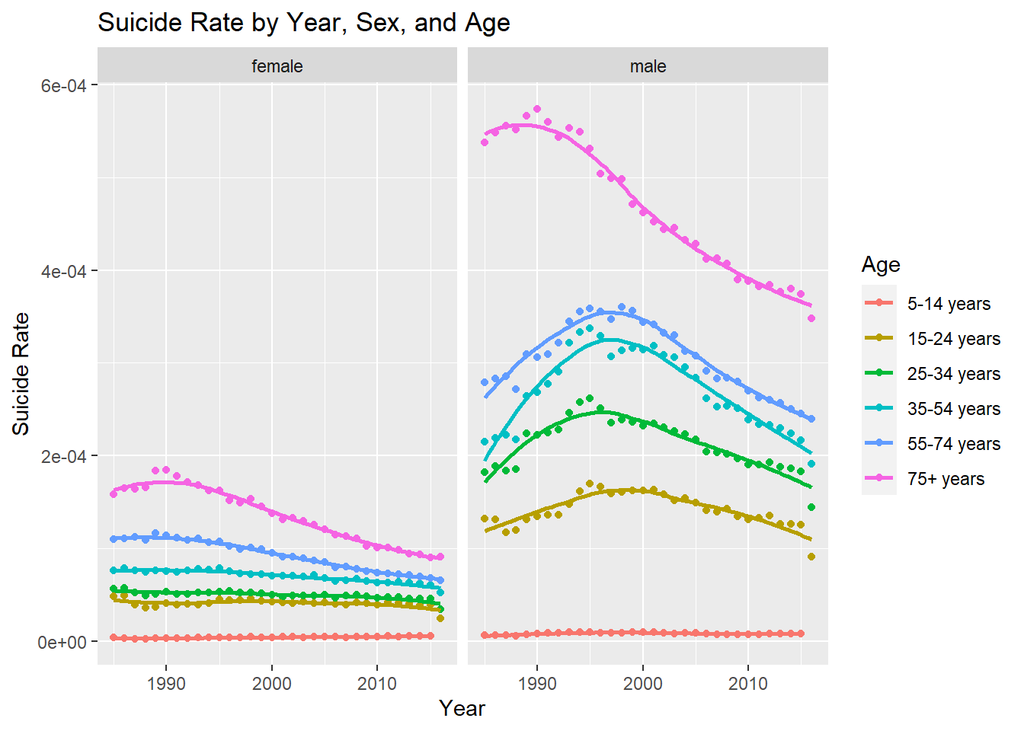

```r
p4
```

Without accounting for the other variables, there is an overall trend of suicide rates increasing up until around 1996 and 1997 then decreasing after this point in time. At the moment, we are not certain if there is a particular world event and/or global economic trend that is responsible for this observation, but it is interesting nonetheless and is a potential direction for future work. However, this rising and falling pattern of suicide rates over time disappears when localized to partiular age groups and sex. For females, suicide rate appears mostly constant with time with a slight decreases into the 2000’s. The rising/falling pattern of suicide rates over time is only observed in the 25-74 age group. Suicide rates remain somewhat constant over time for those in the 5-24 age range while there is a sharp decrease in suicide rates with time for 75+ individuals. When taking sex and age into account simultaneously, the rising/falling pattern for suicide rates over time is mainly observed in males age 25-74. Another interesting observation is that there is a steep decrease in suicide rates over time for elderly males. A similar decrease is observed for elderly females, but it is not nearly as steep.

Before moving on to the statistical modelling, we construct similar scatter plots with overlayed smooth curves for suicide rates vs GDP while accounting for the categorical variables of sex and age.

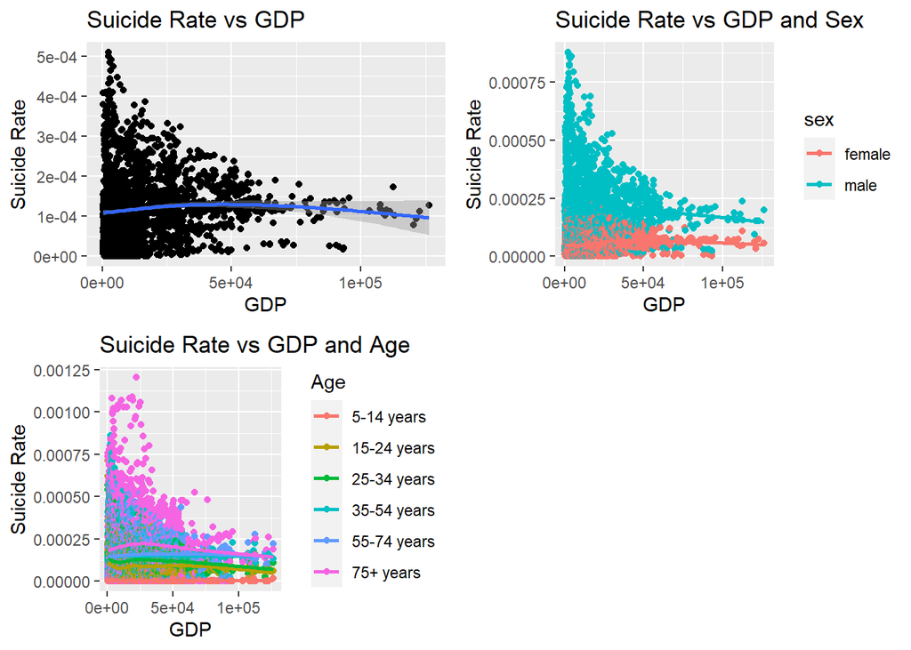

```r
# SQL queries are stored for potential future use. The multiple uses of 'sum()' is cumbersome, so we only fully compute it when we have to.

gdp_query <- suic_db %>% filter(!is.na(GDP)) %>% group_by(GDP) %>%
  summarise(suicides_prop = sum(suicides_no, na.rm = T)/sum(population, na.rm = T))

gdp_sex_query <- suic_db %>% filter(!is.na(GDP)) %>% group_by(GDP, sex) %>%
  summarise(suicides_prop = sum(suicides_no, na.rm = T)/sum(population, na.rm = T))

gdp_age_query <- suic_db %>% filter(!is.na(GDP)) %>% group_by(GDP, age) %>%
  summarise(suicides_prop = sum(suicides_no, na.rm = T)/sum(population, na.rm = T))

gdp_sex_age_query <- suic_db %>% filter(!is.na(GDP)) %>% group_by(GDP, sex, age) %>%
  summarise(suicides_prop = sum(suicides_no, na.rm = T)/sum(population, na.rm = T))

# suicide rate vs GDP
p1 <- gdp_query %>%
  ggplot(aes(x = GDP, y = suicides_prop)) + geom_point() + geom_smooth() + xlab('GDP') + ylab('Suicide Rate') +
  labs(title = 'Suicide Rate vs GDP')

# suicide rate vs GDP and sex
p2 <- gdp_sex_query %>%
  ggplot(aes(x = GDP, y = suicides_prop)) + geom_point(aes(color = sex)) + geom_smooth(aes(color = sex), se = F) +
  xlab('GDP') + ylab('Suicide Rate') + labs(title = 'Suicide Rate vs GDP and Sex')

# suicide rate vs GDP and age
p3 <- gdp_age_query %>%
  ggplot(aes(x = GDP, y = suicides_prop)) + geom_point(aes(color = fct_relevel(age, age_order))) + geom_smooth(aes(color = age), se = F) +
  xlab('GDP') + ylab('Suicide Rate') + labs(title = 'Suicide Rate vs GDP and Age', color = 'Age')

# suicide vs GDP, sex, and age
p4 <- gdp_sex_age_query %>%
  ggplot(aes(x = GDP, y = suicides_prop)) + geom_point(aes(color = sex)) + geom_smooth(aes(color = sex), se = F) +
  xlab('GDP') + ylab('Suicide Rate') + labs(title = 'Suicide Rate vs GDP, Sex, and Age') + facet_wrap(~ fct_relevel(age, age_order))

grid.arrange(p1, p2, p3, nrow = 2)
```

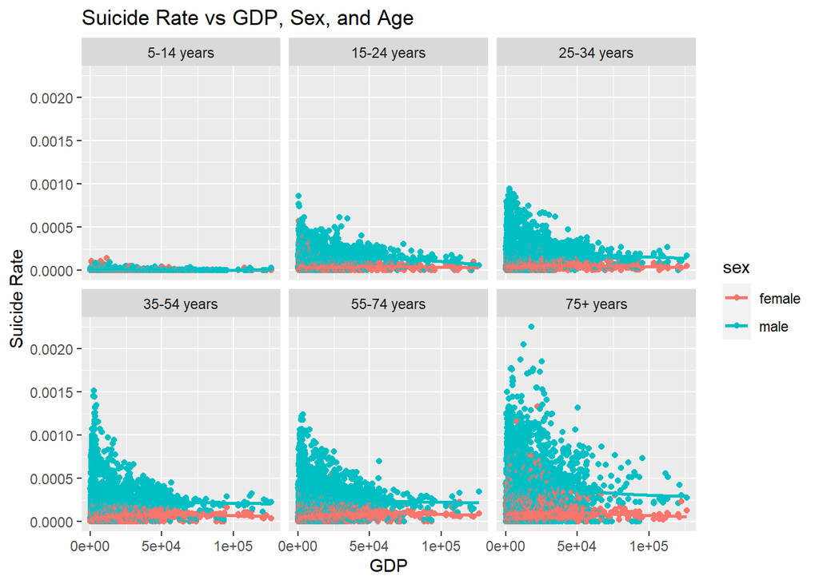

```r
p4
```

The interesting thing about these plots is that if the smooth curves were absent, one would think that there is an overall trend of suicide rates decreasing with GDP where this decrease is initially sharp and then slows down. However, the smooth curves indicate that on average, suicide rates remain mostly constant with GDP with perhaps a slight decrease. This discrepancy in interpretation is due to the many observations of low AND high suicide rates for small values of GDP. Nonetheless, a distinct and interesting observation from these plots is that when an unusually high suicide rate is observed, it is often within a country with low GDP. This observation is more present for males aged 25-75+.

## Statistical Modelling

Our initial visualizations revealed that the response, suicides per 100,000 people, is heavily skewed to the right due to the large amount of zero and small-valued number of suicides. In fact, about 15% of the data has a value of zero for the response. Due to the potential problems from fitting a model on a continuous response with a large amount of zeros, we will use a *two-stage hurdle model*. That is, we will first fit a model to classify the binary response of zero vs non-zero suicides per 100,00 people. Then we will fit a separate model to predict the continuous non-zero suicide rates. For the former, we will use *logistic regression* while for the latter, we will use *Gamma regression* sine the non-zero suicide rates are still heavily skewed right. This is an appropriate modelling procedure because the large amount of zero-valued responses are still included and taken into account but not in a way that raises computational issues. We also gain the advantage of being able to determine the features that distinguish the zero suicide rates from the non-zero suicide rates with respect to our independent variables of interest.

Each modelling stage will use the independent variables of sex, age, and GDP. We center and scale GDP to handle its own skewed nature. As for the effect of different countries, there are far too many levels to include it as a typical categorical variable. Also, there is reason to believe that there are overall patterns relating suicide rates to sex, age, and GDP that are similar across all countries. While countries might not individually provide distinct and identifiable effects on suicide rates, they might provide an additional source of variability of suicide rates. For this reason, we will fit *mixed effects models* to account for this additional source of variability introduced by the different countries. A mixed effets model is appropriate since we will treat country as a random effect while treating GDP, sex, and age as usual fixed effects. Specifically, we will fit a *random intercept model*. That is, the effect of each country is represented as a random change to the intercept of the model. For both the logistic and Gamma regression models, we will compare the model performance with and without the inclusion of country as a random effect. In the end, we will have fit *generalized linear mixed effects models*.

```r
# Add new binary response indicating 0 or > 0 suicides
# Standardize GDP for model performance
# set baseline level for age
binary_suic <- suic_db %>% collect() %>%
  mutate(suicides_yn = if_else(suicides_100k == 0,0,1), GDP_std = (GDP-mean(GDP))/sd(GDP), age = as.factor(age),
         age = relevel(age, ref = '5-14 years'))

# Logistic regression: all fixed effects
LogisticReg_FixedEffects <- glm(suicides_yn ~ sex + age + GDP_std, data = binary_suic, family = binomial)

# random effect for country
LogisticReg_MixedEffects <- glmer(suicides_yn ~ sex + age + GDP_std +
                             (1|country), data = binary_suic, family = binomial)

summary(LogisticReg_FixedEffects)
```

```
##
## Call:
## glm(formula = suicides_yn ~ sex + age + GDP_std, family = binomial,
##     data = binary_suic)
##
## Deviance Residuals:
##     Min       1Q   Median       3Q      Max
## -2.6128   0.3636   0.4570   0.5826   1.0338
##
## Coefficients:
##                Estimate Std. Error z value Pr(>|z|)
## (Intercept)     0.47546    0.03561   13.35  < 2e-16 ***
## sexmale         0.61400    0.03510   17.49  < 2e-16 ***
## age15-24 years  1.35159    0.05703   23.70  < 2e-16 ***
## age25-34 years  1.49232    0.05924   25.19  < 2e-16 ***
## age35-54 years  1.71132    0.06318   27.09  < 2e-16 ***
## age55-74 years  1.24900    0.05555   22.48  < 2e-16 ***
## age75+ years    0.64690    0.04902   13.20  < 2e-16 ***
## GDP_std         0.14558    0.01888    7.71 1.26e-14 ***
## ---
## Signif. codes:  0 '***' 0.001 '**' 0.01 '*' 0.05 '.' 0.1 ' ' 1
##
## (Dispersion parameter for binomial family taken to be 1)
##
##     Null deviance: 23891  on 27819  degrees of freedom
## Residual deviance: 22194  on 27812  degrees of freedom
## AIC: 22210
##
## Number of Fisher Scoring iterations: 5
```

```r
summary(LogisticReg_MixedEffects)
```

```
## Generalized linear mixed model fit by maximum likelihood (Laplace
##   Approximation) [glmerMod]
##  Family: binomial  ( logit )
## Formula: suicides_yn ~ sex + age + GDP_std + (1 | country)
##    Data: binary_suic
##
##      AIC      BIC   logLik deviance df.resid
##   9570.3   9644.4  -4776.1   9552.3    27811
##
## Scaled residuals:
##      Min       1Q   Median       3Q      Max
## -11.8873   0.0115   0.0486   0.1485  14.0441
##
## Random effects:
##  Groups  Name        Variance Std.Dev.
##  country (Intercept) 15.49    3.936
## Number of obs: 27820, groups:  country, 101
##
## Fixed effects:
##                Estimate Std. Error z value Pr(>|z|)
## (Intercept)     0.35102    0.40304   0.871   0.3838
## sexmale         1.49094    0.05780  25.796   <2e-16 ***
## age15-24 years  3.56783    0.10545  33.836   <2e-16 ***
## age25-34 years  3.89994    0.10926  35.695   <2e-16 ***
## age35-54 years  4.38281    0.11501  38.107   <2e-16 ***
## age55-74 years  3.31416    0.10252  32.326   <2e-16 ***
## age75+ years    1.68298    0.08286  20.311   <2e-16 ***
## GDP_std         0.11774    0.05058   2.328   0.0199 *
## ---
## Signif. codes:  0 '***' 0.001 '**' 0.01 '*' 0.05 '.' 0.1 ' ' 1
##
## Correlation of Fixed Effects:
##             (Intr) sexmal a15-2y a25-3y a35-5y a55-7y ag75+y
## sexmale     -0.062
## age15-24yrs -0.074  0.158
## age25-34yrs -0.074  0.174  0.521
## age35-54yrs -0.074  0.196  0.519  0.525
## age55-74yrs -0.074  0.146  0.514  0.515  0.511
## age75+years -0.076  0.091  0.437  0.430  0.417  0.442
## GDP_std      0.005  0.012  0.019  0.019  0.020  0.018  0.011
```

```r
# Compare fixed vs mixed effects model in terms of classification accuracy
pred_randomCountry <- if_else(predict(LogisticReg_MixedEffects, type = 'response') >= 0.5,1,0)
pred_fixed <- if_else(predict(LogisticReg_FixedEffects, type = 'response') >= 0.5,1,0)

cat('Classification accuracy of fixed effects logistic regression: ',
    mean(pred_fixed == binary_suic$suicides_yn))
```

```
## Classification accuracy of fixed effects logistic regression:  0.8461179
```

```r
cat('Classification accuracy of mixed effects logistic regression: ',
    mean(pred_randomCountry == binary_suic$suicides_yn))
```

```
## Classification accuracy of mixed effects logistic regression:  0.9300863
```

Both the fixed and mixed effects logistic regression models yield similar results in terms of significant predictors. All variables are significant (alpha = 0.05) for predicting the probability of a non-zero suicide rate. As for the direction of the effects, males have a higher probablity of a non-zero suicide rate than females. As for age, 5-14 years has the lowest probability of a non-zero suicide rate while 35-54 years has the highest. Increasing GDP increases the probability of a non-zero suicide rate. In terms of significant predictors, the only difference between the two models is that when accounting for random differenes due to country, GDP is not as singificant. As for classification accuracy of zero vs non-zero suicide rates, the mixed effects model performs better than the fixed effects model. In fact, the fixed effects model classified every observation as having a non-zero suicide rate. By including country as a random effect, we are able to achieve increased classification accuracy. We visualize and compare the prediction performance of the two models in the figures below.

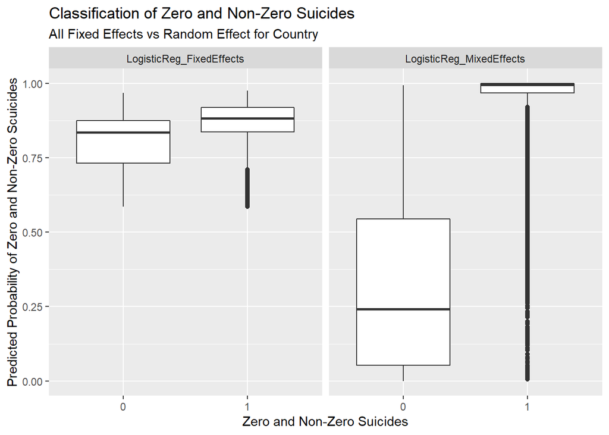

```r
# add predicted values for plotting
logreg_predictions <- binary_suic %>% gather_predictions(LogisticReg_FixedEffects, LogisticReg_MixedEffects, type = 'response')

# predicted probabilities of fixed vs mixed effects model
logreg_predictions %>%
    ggplot(aes(x = as.factor(suicides_yn), y = pred)) + geom_boxplot() + facet_wrap(~ model) +
    xlab('Zero and Non-Zero Suicides') + ylab('Predicted Probability of Zero and Non-Zero Scuicides') +
    labs(title = 'Classification of Zero and Non-Zero Suicides',
         subtitle = 'All Fixed Effects vs Random Effect for Country')
```

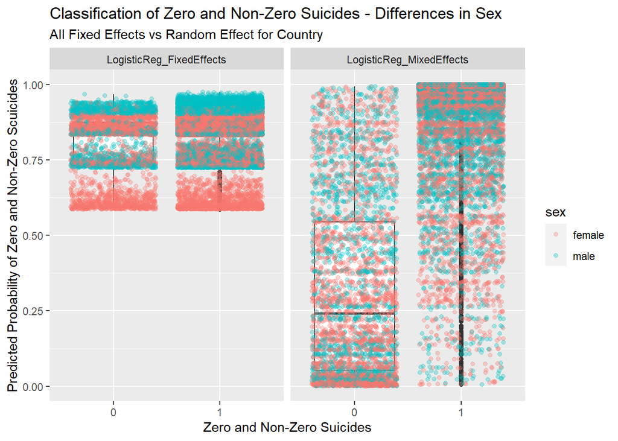

```r
# prediction in terms of sex
logreg_predictions %>%
    ggplot(aes(x = as.factor(suicides_yn), y = pred)) + geom_boxplot() +
    geom_point(aes(color = sex), alpha = 0.3, position = 'jitter') + facet_wrap(~ model) +
    xlab('Zero and Non-Zero Suicides') + ylab('Predicted Probability of Zero and Non-Zero Scuicides') +
    labs(title = 'Classification of Zero and Non-Zero Suicides - Differences in Sex',
         subtitle = 'All Fixed Effects vs Random Effect for Country')
```

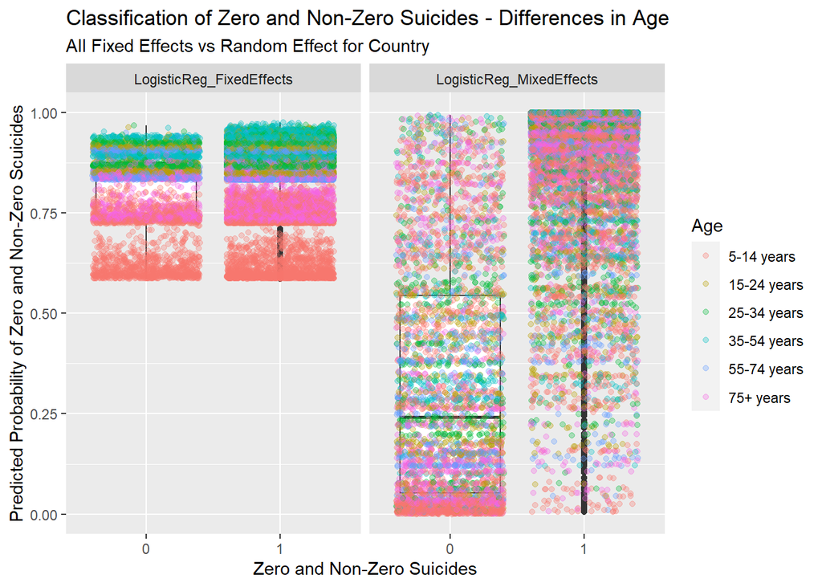

```r
# prediction in terms of age
logreg_predictions %>%
    ggplot(aes(x = as.factor(suicides_yn), y = pred)) + geom_boxplot() +
    geom_point(aes(color = fct_relevel(age, age_order)), alpha = 0.3, position = 'jitter') + facet_wrap(~ model) +
    xlab('Zero and Non-Zero Suicides') + ylab('Predicted Probability of Zero and Non-Zero Scuicides') +
    labs(title = 'Classification of Zero and Non-Zero Suicides - Differences in Age',
         subtitle = 'All Fixed Effects vs Random Effect for Country', color = 'Age')
```

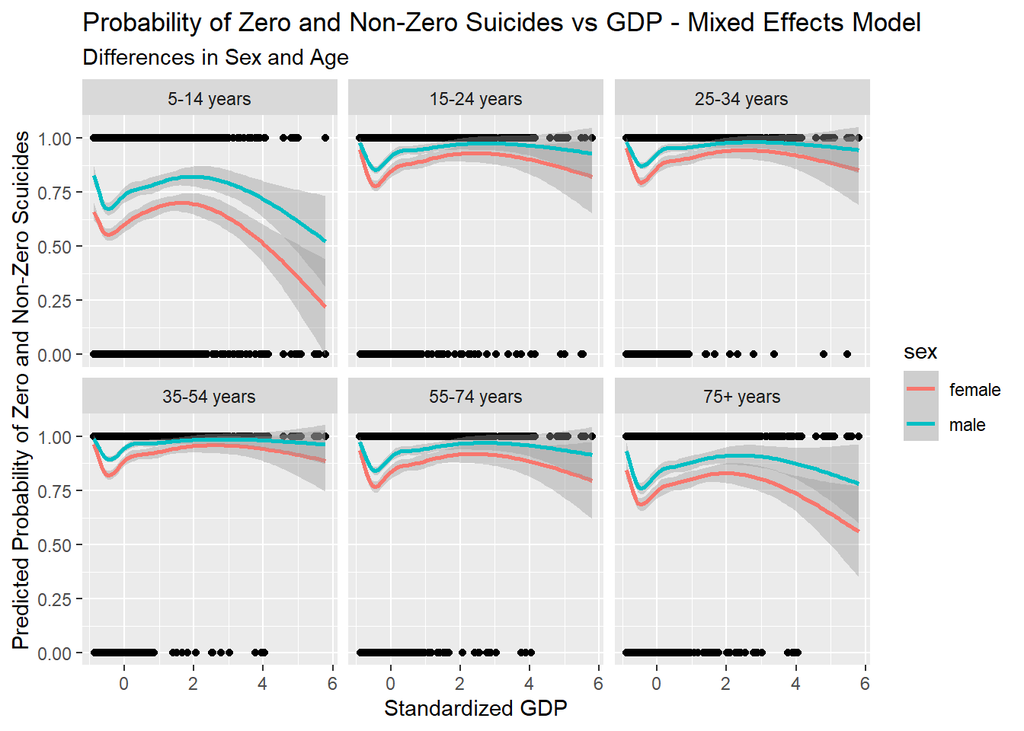

```r
# prediction in terms of sex, age, and GDP from mixed effects model
binary_suic %>% gather_predictions(LogisticReg_MixedEffects, type = 'response') %>%
    ggplot(aes(x = GDP_std)) + geom_point(aes(y = suicides_yn)) +
    geom_smooth(aes(y = pred, color = sex)) + facet_wrap(~ fct_relevel(age, age_order)) +
    xlab('Standardized GDP') + ylab('Predicted Probability of Zero and Non-Zero Scuicides') +
    labs(title = 'Probability of Zero and Non-Zero Suicides vs GDP - Mixed Effects Model',
         subtitle = 'Differences in Sex and Age')
```

From the first plot, it is evident that the typical fixed effects model (where country is not included) classifies all observations as having a non-zero suicide rate; all predicted probabilities of a non-zero suicide rate are well above 0.5. In contrast to this, the mixed effects model (where country is included) accurately predicts small probabilities for most of the zero suicide rate observations and large probabilities for most of the non-zero suicide rate observations. Based on the boxplot, the non-zero suicide rates (value of 1) tend to be more accurately classified by the mixed effects model than the zero-valued suicide rates (value of 0). In terms of sex (second figure), the misclassified observations look to be an even mix of male and female groups. Female groups tend to be classified as having zero-valued suicide rates while male groups tend to be classified as having non-zero suicide rates. As for age, we similarly see the misclassified observations being a somewhat even mix of all age groups. When an observation is classified as having a zero-valued suicide rate, it tends to be from the very young (5-14) or very old (75+) age groups. When an observation is classified as having a non-zero suicide rate, it could be from any age group. In the last figure, we see an overall pattern relating the predicted probability of non-zero suicide rate to GDP that holds regardless of sex and age: for small values of GDP, the probablity increases with GDP while for large values of GDP, the probability starts to decrease with GDP.

Now we are ready to focus our attention on modelling the non-zero suicide rates, and we will do so with a Gamma regression model since the distribution of the non-zero suicide rates is still heavily skewed to the right from the large amount of small values. Similar to our previous model, we will fit a Gamma regression model with and without a random effect for country and compare the two models. We also plot the residuals to assess the appropriateness of a Gamma regression model.

```r
# Extract > 0 suicide rate data subset
positive_suic <- suic_db %>% filter(suicides_100k > 0) %>% collect() %>%
  mutate(GDP_std = (GDP-mean(GDP))/sd(GDP), age = as.factor(age), age = relevel(age, ref = '5-14 years'))


# Gamma regression model with all fixed effects
GammaReg_FixedEffects <- glm(suicides_100k ~ sex + age + GDP_std, data = positive_suic,
                             family = Gamma(link = 'log'))

# Gamma regression model with random effect for country
GammaReg_MixedEffects <- glmer(suicides_100k ~ sex + age + GDP_std + (1|country),
                               data = positive_suic, family = Gamma(link = 'log'))

summary(GammaReg_FixedEffects)
```

```
##
## Call:
## glm(formula = suicides_100k ~ sex + age + GDP_std, family = Gamma(link = "log"),
##     data = positive_suic)
##
## Deviance Residuals:
##     Min       1Q   Median       3Q      Max
## -2.9465  -0.7717  -0.2301   0.2994   6.7787
##
## Coefficients:
##                 Estimate Std. Error t value Pr(>|t|)
## (Intercept)    -0.654169   0.017466 -37.455  < 2e-16 ***
## sexmale         1.127075   0.011896  94.741  < 2e-16 ***
## age15-24 years  2.241947   0.021583 103.873  < 2e-16 ***
## age25-34 years  2.460321   0.021519 114.334  < 2e-16 ***
## age35-54 years  2.662478   0.021430 124.239  < 2e-16 ***
## age55-74 years  2.817840   0.021640 130.216  < 2e-16 ***
## age75+ years    3.284287   0.022094 148.648  < 2e-16 ***
## GDP_std        -0.033591   0.005944  -5.651 1.61e-08 ***
## ---
## Signif. codes:  0 '***' 0.001 '**' 0.01 '*' 0.05 '.' 0.1 ' ' 1
##
## (Dispersion parameter for Gamma family taken to be 0.8311146)
##
##     Null deviance: 38516  on 23538  degrees of freedom
## Residual deviance: 16804  on 23531  degrees of freedom
## AIC: 151076
##
## Number of Fisher Scoring iterations: 6
```

```r
summary(GammaReg_MixedEffects)
```

```
## Generalized linear mixed model fit by maximum likelihood (Laplace
##   Approximation) [glmerMod]
##  Family: Gamma  ( log )
## Formula: suicides_100k ~ sex + age + GDP_std + (1 | country)
##    Data: positive_suic
##
##      AIC      BIC   logLik deviance df.resid
## 133211.3 133291.9 -66595.6 133191.3    23529
##
## Scaled residuals:
##     Min      1Q  Median      3Q     Max
## -1.5469 -0.6264 -0.1358  0.4193 23.0026
##
## Random effects:
##  Groups   Name        Variance Std.Dev.
##  country  (Intercept) 0.2490   0.4990
##  Residual             0.4005   0.6329
## Number of obs: 23539, groups:  country, 99
##
## Fixed effects:
##                 Estimate Std. Error t value Pr(>|z|)
## (Intercept)    -0.820315   0.079272  -10.35   <2e-16 ***
## sexmale         1.122865   0.007651  146.75   <2e-16 ***
## age15-24 years  2.219092   0.013716  161.79   <2e-16 ***
## age25-34 years  2.406903   0.013861  173.65   <2e-16 ***
## age35-54 years  2.563116   0.013888  184.55   <2e-16 ***
## age55-74 years  2.707794   0.014064  192.53   <2e-16 ***
## age75+ years    3.161689   0.014488  218.23   <2e-16 ***
## GDP_std        -0.136240   0.007101  -19.19   <2e-16 ***
## ---
## Signif. codes:  0 '***' 0.001 '**' 0.01 '*' 0.05 '.' 0.1 ' ' 1
##
## Correlation of Fixed Effects:
##             (Intr) sexmal a15-2y a25-3y a35-5y a55-7y ag75+y
## sexmale     -0.036
## age15-24yrs -0.095 -0.082
## age25-34yrs -0.095 -0.123  0.581
## age35-54yrs -0.097 -0.112  0.580  0.595
## age55-74yrs -0.096 -0.099  0.572  0.586  0.596
## age75+years -0.093 -0.119  0.556  0.571  0.581  0.583
## GDP_std      0.002  0.000  0.010  0.019  0.010  0.019  0.031
```

```r
# compare the two models with Deviance residuals
cat('Sum of squared Deviance residuals for fixed effects Gamma regression: ',
    sum(resid(GammaReg_FixedEffects, type = 'deviance')^2))
```

```
## Sum of squared Deviance residuals for fixed effects Gamma regression:  16803.74
```

```r
cat('Sum of squared Deviance residuals for mixed effects Gamma regression: ',
    sum(resid(GammaReg_MixedEffects, type = 'deviance')^2))
```

```
## Sum of squared Deviance residuals for mixed effects Gamma regression:  8155.297
```

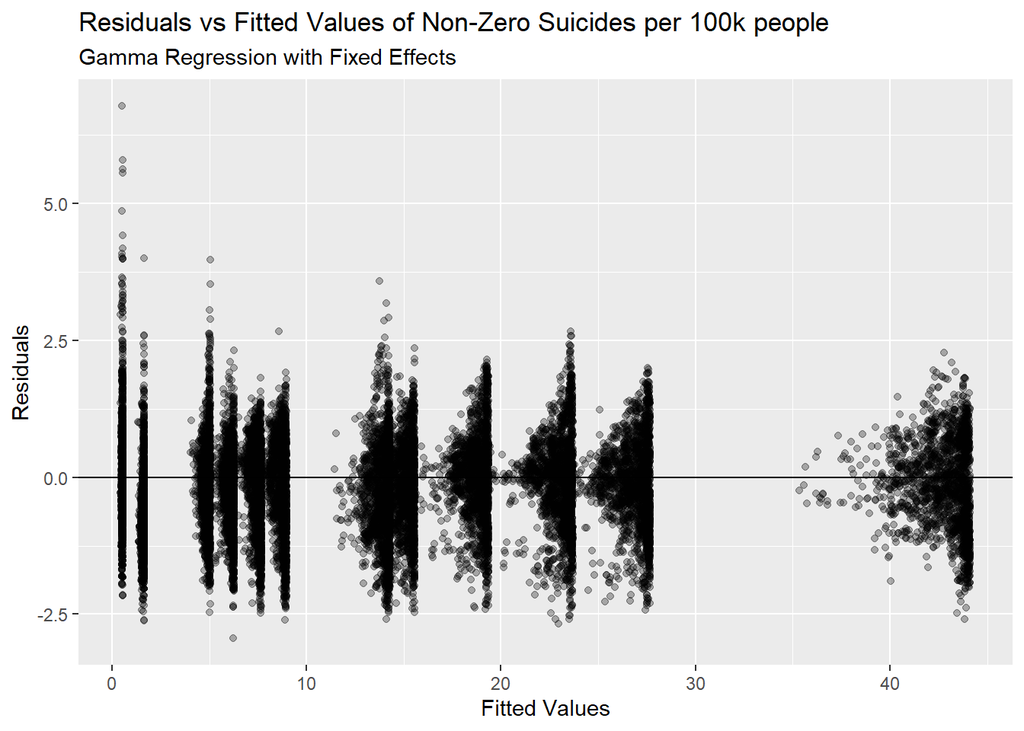

```r
# Deviance residual plots for both models
ggplot() +
  geom_point(aes(x = fitted(GammaReg_FixedEffects), y = resid(GammaReg_FixedEffects, type='deviance')),
             alpha = 0.3) + geom_hline(aes(yintercept = 0)) + xlab('Fitted Values') +
  ylab('Residuals') + labs(title = 'Residuals vs Fitted Values of Non-Zero Suicides per 100k people',
                           subtitle = 'Gamma Regression with Fixed Effects')
```

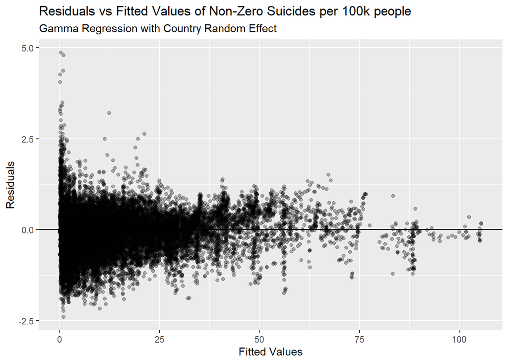

```r
ggplot() +
  geom_point(aes(x = fitted(GammaReg_MixedEffects), y = resid(GammaReg_MixedEffects, type='deviance')),
             alpha = 0.3) + geom_hline(aes(yintercept = 0)) + xlab('Fitted Values') +
  ylab('Residuals') + labs(title = 'Residuals vs Fitted Values of Non-Zero Suicides per 100k people',
                           subtitle = 'Gamma Regression with Country Random Effect')
```

First, lets investigate the appropriateness of a Gamma regression model by looking at the residual plots. Ideally, we would like to see an even spread of residuals in the positive and negative direction regardless of the predicted value for suicide rate. However, for both the fixed and mixed effects model, we have some larger in magnitude residuals for small predicted values compared to the residuals for large predicted values. This indicates that the Gamma specification for the distribution of the response might not be ideal. However, if we ignore the extreme residual outliers present for very small (near zero) predicted values, then this issue is not severe. We are confident that the Gamma regression models can still provide us with meaningful results with the caveat that model specification for small values of suicide rate is not ideal.

Now let’s compare the fixed and mixed effects Gamma models in terms of significance of predictors. For both models, all predictors - sex, age, GDP - are very significant (any alpha) in predicting suicide rate. In fact, all p-values for both models are near zero. In terms of the direction of these effects, both models yield the same results. Males have an increased predicted suicide rate compared to females. The youngest 5-14 age group (reference level for age) has the smallest predicted suicide rate while the oldest 75+ age group has the largest predicted suicide rate. As for GDP, increasing GDP is associated with a decreasing predicted suicide rate. The two models do, however, differ in terms of prediction error. For a comparison metric, let’s look at the sum of squared deviance residuals, which is just the usual sum of squared residuals in the linear model case but augmented to account for the generalized linear model. It can be viewed as a measure of the overall prediction error of the model. By including country as a random effect, we nearly cut the sum of squared deviance residuals in half! This is evidence in support of the mixed effects model over the fixed effects model and suggests that accounting for country is worthwhile for predicting suicide rate.

Now we visualize the performance of the preferred mixed effects model (with country included) in terms of predicting non-zero suicide rate. The figure below displays the predicted suicide rate vs age, sex, and GDP.

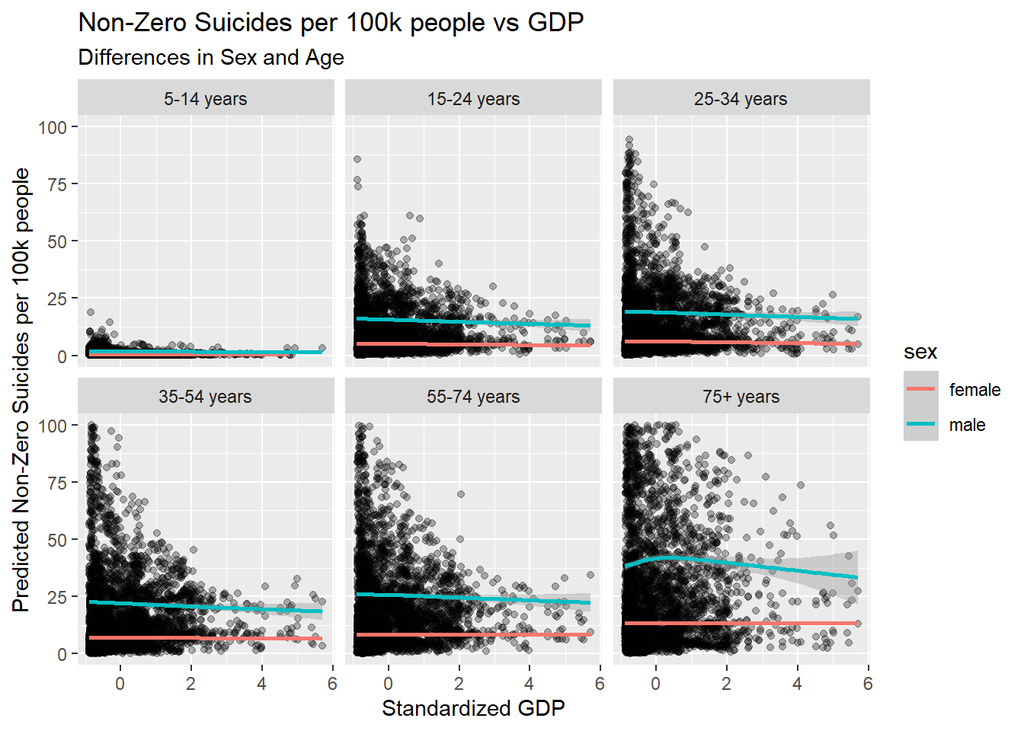

```r
# predicted > 0 suicide rate vs age, sex, and GDP from the mixed effects Gamma regression model
gammareg_pred_plot <- positive_suic %>% gather_predictions(GammaReg_MixedEffects, type = 'response') %>%
    ggplot(aes(x = GDP_std)) + geom_point(aes(y = suicides_100k), alpha = 0.3) +
    geom_smooth(aes(y = pred, color = sex)) + facet_wrap(~ fct_relevel(age, age_order)) + xlab('Standardized GDP') +
    ylab('Predicted Non-Zero Suicides per 100k people') +
    labs(title = 'Non-Zero Suicides per 100k people vs GDP',
         subtitle = 'Differences in Sex and Age')

gammareg_pred_plot + ylim(0,100)
```

From the figure, we see the clear increased predicted suicide rate for males compared to females although this difference is not noticable for the youngest (5-14) age group. The gap between predicted suicide rate for males and females seems to widen with age. As for GDP, we do see an overall decrease in predicted suicide rate as GDP increases. This decrease is more noticeable for males and the older age groups of 35-75+.